# Linear regression

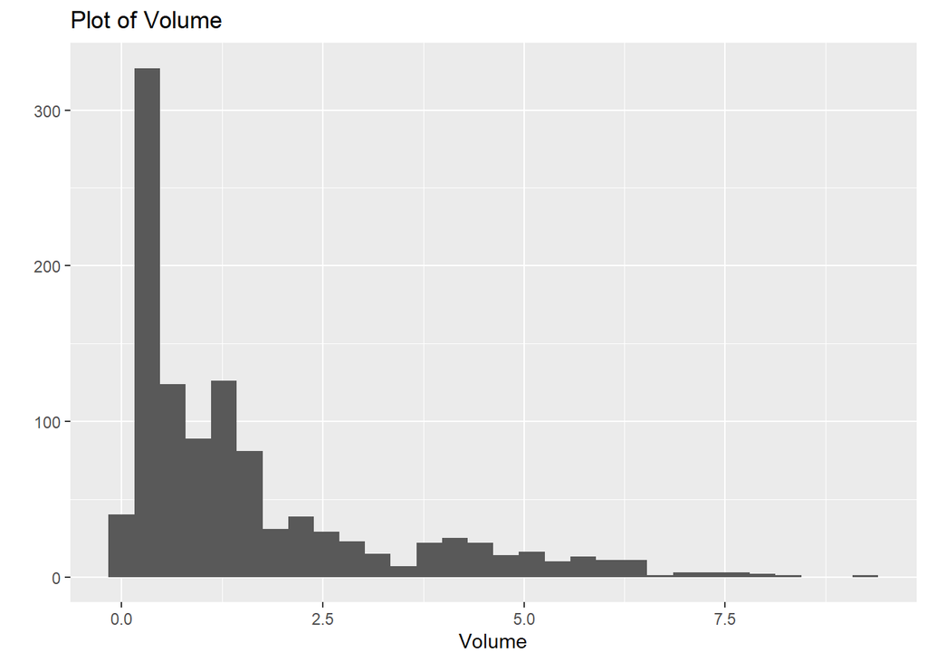

```r
qplot(Volume, main="Plot of Volume")
```

```r
#ggplot(Volume,aes(x=Index, y=Volume))+geom_point(size=1.5)
```

Now, we will use the full data set to perform a logistic regression with Direction as the response and the five lag variables plus Volume as predictors. We will use the summary function to print the results and also examine if any of the predictors appear to be statistically significant. If so, we will also find them below.

```r
model.4.7.10.b=glm(Direction~.-Year-Today,data=Weekly,family = binomial)
summary(model.4.7.10.b)
```

```
##
## Call:
## glm(formula = Direction ~ . - Year - Today, family = binomial,
##     data = Weekly)
##
## Coefficients:
##             Estimate Std. Error z value Pr(>|z|)
## (Intercept)  0.26686    0.08593   3.106   0.0019 **
## Lag1        -0.04127    0.02641  -1.563   0.1181
## Lag2         0.05844    0.02686   2.175   0.0296 *
## Lag3        -0.01606    0.02666  -0.602   0.5469
## Lag4        -0.02779    0.02646  -1.050   0.2937
## Lag5        -0.01447    0.02638  -0.549   0.5833
## Volume      -0.02274    0.03690  -0.616   0.5377
## ---
## Signif. codes:  0 '***' 0.001 '**' 0.01 '*' 0.05 '.' 0.1 ' ' 1
##
## (Dispersion parameter for binomial family taken to be 1)
##
##     Null deviance: 1496.2  on 1088  degrees of freedom
## Residual deviance: 1486.4  on 1082  degrees of freedom
## AIC: 1500.4
##
## Number of Fisher Scoring iterations: 4
```

Based on the summary of the model, only Lag2 variable is statistically significant (at P<0.05). The estimated coefficient for this variable is 0.05844, which means we would expect mean increase of the log odd in favor of the market going up by a unit increase in Lag2 variable, keeping other predictors in the model constant.

Here, we will compute the confusion matrix and overall fraction of correct predictions. Explain what the confusion matrix is telling you about the types of mistakes made by logistic regression.

```r
computeIT=function(TH,model,data){
  preds=rep("Down",dim(data)[1])
  vals=predict(model,newdata=data,type="response")
  for(i in 1:dim(data)[1]){
    if(vals[i]>=TH){
      preds[i]="Up"
    }
  }
  ## Confusion matrix
  cat("Confusion Matrix:")
  con=table(preds,data$Direction)
  print(con)
  cat("Model Accuracy (Percentage):")
  print(round(sum(preds==data$Direction)/dim(data)[1]*100,2))
  cat("True Postive Rate, TPR (percentage):")
  print(round(con[2,2]/(con[2,2]+con[1,2])*100,2))
  cat("False Postive Rate, FPR (percentage):")
  spec=con[1,1]/(con[1,1]+con[2,1])*100
  print(round((100-spec),2))

}
computeIT(0.5,model.4.7.10.b,Weekly)
```

```
## Confusion Matrix:
## preds  Down  Up
##   Down   54  48
##   Up    430 557
## Model Accuracy (Percentage):[1] 56.11
## True Postive Rate, TPR (percentage):[1] 92.07
## False Postive Rate, FPR (percentage):[1] 88.84
```

In a good model we would expect large TPR and low FPR. In this analysis, using a threshold value of 0.5, the overall accuracy of the model is only 56.11%. Based on the confusion matrix, the True Positive Rate (TPR) of the model was calculated to be 92.07%, which is very good. The model gives 92.07% of the time right prediction, when the market goes up. But the thing that makes model very bad is the False Positive Rate (FRP). FPR for the model was calculated to be 88.84% (Specificity=11.16%) which means when the market is going Down, 88.84% of the time the model is predicting market to be going up, falsely.

Now, we will fit the logistic regression model using a training data period from 1990 to 2008, with Lag2 as the only predictor. Then compute the confusion matrix and the overall fraction of correct predictions for the held out data (that is, the data from 2009 and 2010).

```r
index=c(which(Weekly$Year==2009), which(Weekly$Year==2010))
train=Weekly[-index,]
test=Weekly[index,]
model.4.7.10.d=glm(Direction~Lag2,data=train,family = binomial)
summary(model.4.7.10.d)
```

```
##
## Call:
## glm(formula = Direction ~ Lag2, family = binomial, data = train)
##
## Coefficients:
##             Estimate Std. Error z value Pr(>|z|)
## (Intercept)  0.20326    0.06428   3.162  0.00157 **
## Lag2         0.05810    0.02870   2.024  0.04298 *
## ---
## Signif. codes:  0 '***' 0.001 '**' 0.01 '*' 0.05 '.' 0.1 ' ' 1
##
## (Dispersion parameter for binomial family taken to be 1)
##
##     Null deviance: 1354.7  on 984  degrees of freedom
## Residual deviance: 1350.5  on 983  degrees of freedom
## AIC: 1354.5
##
## Number of Fisher Scoring iterations: 4
```

```r
## Calculations for held out data
summary(test$Direction)
```

```
## Down   Up
##   43   61
```

```r
computeIT(0.5,model.4.7.10.d,test)
```

```
## Confusion Matrix:
## preds  Down Up
##   Down    9  5
##   Up     34 56
## Model Accuracy (Percentage):[1] 62.5
## True Postive Rate, TPR (percentage):[1] 91.8
## False Postive Rate, FPR (percentage):[1] 79.07
```

For the held out data (data from 2009 and 2010), the calculations were done as before. At a threshold value of 0.5, the model accuracy was 62.5%. There were 43 Down and 61 Up cases in the held out data. The model gave a decent TPR value of 91.8%. However, it was reasonably bad in the sense of FPR, with a value of 79.07%.

In this problem, we will develop a model to predict whether a given car gets high or low gas mileage based on the Auto data set.

We will first, create a binary variable, mpg01, that contains a 1 if mpg contains a value above its median, and a 0 if mpg contains a value below its median. You can compute the median using the median() function. Note we may find it helpful to use the data.frame() function to create a single data set containing both mpg01 and the other Auto variables.

```r
library(ISLR)
data(Auto)
mpg01=rep(NA,dim(Auto)[1])
med=median(Auto$mpg)
mpg01=ifelse(Auto$mpg<med,0,1)
df=as.data.frame(cbind(Auto, mpg01))
```

Here, we will explore the data graphically in order to investigate the association between mpg01 and the other features. We will try to find the features that seem most likely to be useful in predicting mpg01. Scatterplots and boxplots may be useful tools to answer this question.

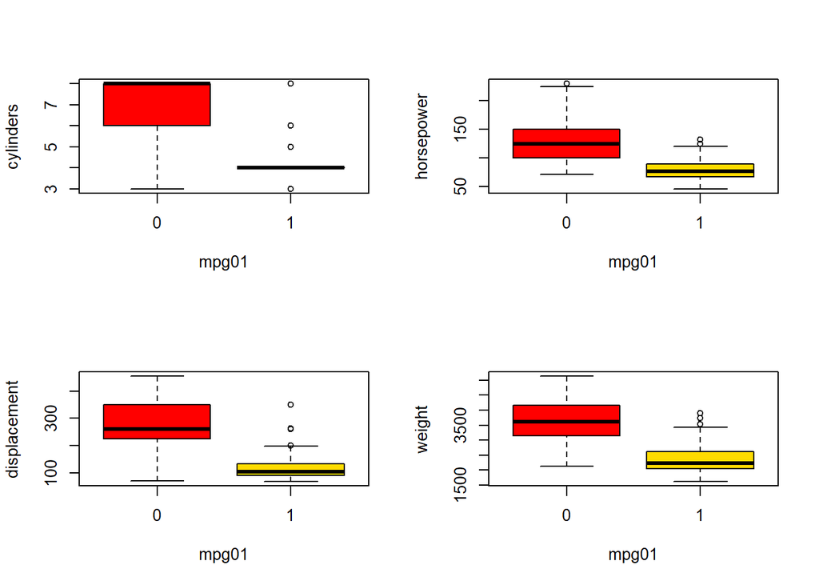

```r
k=c(2,3,4,5,6,7,8) ## taking just the relevant variables
layout(matrix(1:4,nrow = 2))
for(i in k){
  boxplot(df[,i]~df$mpg01,col=rainbow(7),xlab="mpg01",ylab=names(df)[i])
}
```

[figure not shown]

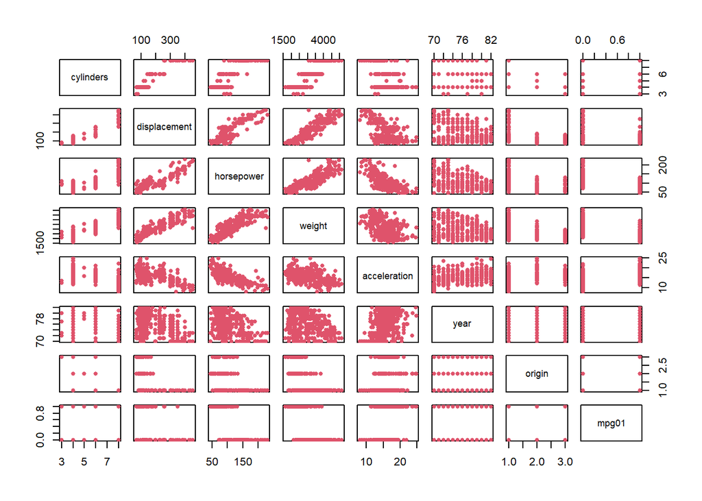

```r
newdf=df[,c(2,3,4,5,6,7,8,10)] ## mpg and names dropped
plot(newdf,pch=16,cex=0.8,col=2)
```

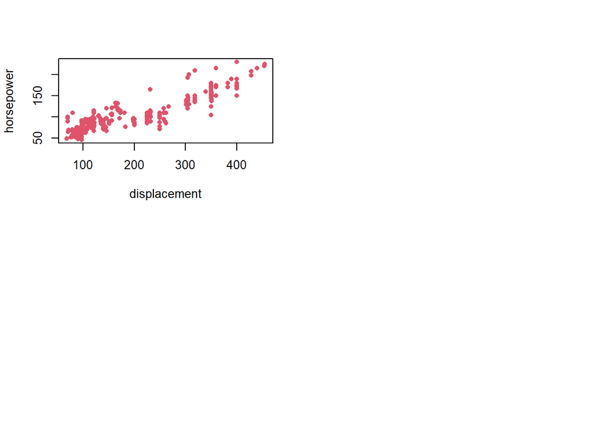

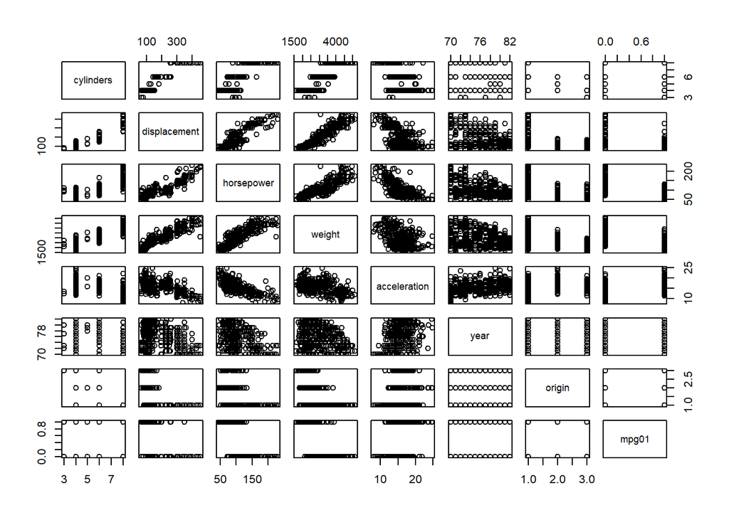

```r
plot(horsepower~displacement,Auto,pch=16,cex=0.8,col=2)

library(ggplot2)
library(GGally)
pairs(newdf) #pairwise correlation
```

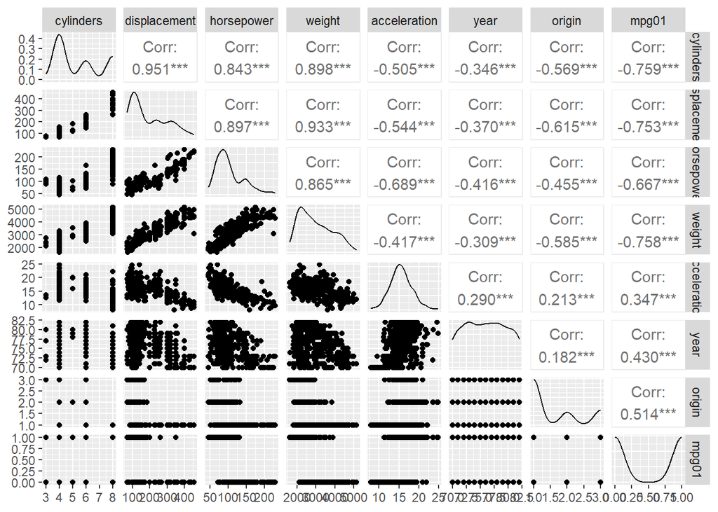

```r
ggpairs(newdf,cardinality_threshold = 304)#ggpairs
```

```r
str(newdf)
```

```
## 'data.frame':    392 obs. of  8 variables:
##  $ cylinders   : num  8 8 8 8 8 8 8 8 8 8 ...
##  $ displacement: num  307 350 318 304 302 429 454 440 455 390 ...
##  $ horsepower  : num  130 165 150 150 140 198 220 215 225 190 ...
##  $ weight      : num  3504 3693 3436 3433 3449 ...
##  $ acceleration: num  12 11.5 11 12 10.5 10 9 8.5 10 8.5 ...
##  $ year        : num  70 70 70 70 70 70 70 70 70 70 ...
##  $ origin      : num  1 1 1 1 1 1 1 1 1 1 ...
##  $ mpg01       : num  0 0 0 0 0 0 0 0 0 0 ...
```

Based on the plots, we see that there is a clear distinction between the distribution of cylinders in two groups. So is the case for horsepower, acceleration, origin, displacement, weight and year. US based cars are mostly condensed at lower mpg, whereas European and Japanese cars tend to be well distributed. Also, older cars tend to have lower mpg, and modern cars tend to have higher. We also expect correlation between the mechanical features of the cars, so from scatter plots it seems that there is very high correlations between the physical quantities.

Now, we will split the data into a training set and a test set.

```r
lowmpg=subset(newdf,mpg01==0)
highmpg=subset(newdf,mpg01==1)

set.seed(1235)
index1=sample((1:dim(lowmpg)[1]),size=round(0.5*dim(lowmpg)[1]),replace=F)
index2=sample((1:dim(highmpg)[1]),size=round(0.5*dim(highmpg)[1]),replace=F)

train1=lowmpg[index1,];   train2=highmpg[index2,] # training dataset 50%
test1=lowmpg[-index1,];   test2=highmpg[-index2,] # test dataset 50%

train=rbind(train1,train2)
test=rbind(test1,test2)
```

The test and training data were created in the ration of 50:50 from high mpg and low mpg groups. Now, we will perform logistic regression on the training data in order to predict mpg01 using the variables that seemed most associated with mpg01. We will then calculate the test errors of the model obtained.

```r
model.4.7.11.f.1=glm(mpg01~.,train,family=binomial)
summary(model.4.7.11.f.1)
```

```
##
## Call:
## glm(formula = mpg01 ~ ., family = binomial, data = train)
##
## Coefficients:
##                Estimate Std. Error z value Pr(>|z|)
## (Intercept)  -20.105957  10.246866  -1.962   0.0497 *
## cylinders      0.309334   0.676704   0.457   0.6476
## displacement  -0.026788   0.018133  -1.477   0.1396
## horsepower    -0.073805   0.041585  -1.775   0.0759 .
## weight        -0.003055   0.001628  -1.877   0.0605 .
## acceleration   0.029016   0.244067   0.119   0.9054
## year           0.499403   0.125860   3.968 7.25e-05 ***
## origin         0.097692   0.519729   0.188   0.8509
## ---
## Signif. codes:  0 '***' 0.001 '**' 0.01 '*' 0.05 '.' 0.1 ' ' 1
##
## (Dispersion parameter for binomial family taken to be 1)
##
##     Null deviance: 271.714  on 195  degrees of freedom
## Residual deviance:  63.159  on 188  degrees of freedom
## AIC: 79.159
##
## Number of Fisher Scoring iterations: 8
```

```r
showStats=function(cutoff,model,test){
  preds=rep(0,dim(test)[1])
  probs=predict(model,newdata=test, type="response")
  for(i in 1:length(probs)){
    if(probs[i]>=cutoff){
      preds[i]=1
    }
  }
  cm=table(preds, test$mpg01)
  cat("Confusion Matrix:");print(cm)
  ac=((cm[1,1]+cm[2,2])/sum(cm))*100
  cat("Overall test accuracy (percentage) : ", round(ac,2))
  cat("Misclassification rate (percantage): ",round((100-ac),2))
  cat("True Postive Rate, TPR/Sensitivity (percentage): ",
          round(cm[2,2]/(cm[2,2]+cm[1,2])*100,2))
  spec=cm[1,1]/(cm[1,1]+cm[2,1])*100
  cat("Specificity (percantage): ",round(spec,2))
  cat("False Postive Rate, FPR (percentage): ",round((100-spec),2))
}

showStats(0.5,model.4.7.11.f.1, test)
```

```
## Confusion Matrix:
## preds  0  1
##     0 83 10
##     1 15 88
## Overall test accuracy (percentage) :  87.24Misclassification rate (percantage):  12.76True Postive Rate, TPR/Sensitivity (percentage):  89.8Specificity (percantage):  84.69False Postive Rate, FPR (percentage):  15.31
```

```r
cat("Looking for influential correlation")
```

```
## Looking for influential correlation
```

```r
library(car)
kable(vif(model.4.7.11.f.1), caption = "VIF of model.4.7.11.f.1")
```

VIF of model.4.7.11.f.1

|  | x |
| --- | --- |
| cylinders | 4.666565 |
| displacement | 6.512828 |
| horsepower | 2.377756 |
| weight | 3.312294 |
| acceleration | 2.372670 |
| year | 1.897841 |
| origin | 1.689610 |

```r
model.4.7.11.f.2=glm(mpg01~.-displacement-cylinders,train,family=binomial)
summary(model.4.7.11.f.2)
```

```
##
## Call:
## glm(formula = mpg01 ~ . - displacement - cylinders, family = binomial,
##     data = train)
##
## Coefficients:
##                Estimate Std. Error z value Pr(>|z|)
## (Intercept)  -19.652677   9.481877  -2.073   0.0382 *
## horsepower    -0.077406   0.038028  -2.035   0.0418 *
## weight        -0.004826   0.001298  -3.720   0.0002 ***
## acceleration   0.058313   0.236611   0.246   0.8053
## year           0.508412   0.119857   4.242 2.22e-05 ***
## origin         0.649451   0.427815   1.518   0.1290
## ---
## Signif. codes:  0 '***' 0.001 '**' 0.01 '*' 0.05 '.' 0.1 ' ' 1
##
## (Dispersion parameter for binomial family taken to be 1)
##
##     Null deviance: 271.714  on 195  degrees of freedom
## Residual deviance:  66.134  on 190  degrees of freedom
## AIC: 78.134
##
## Number of Fisher Scoring iterations: 8
```

```r
kable(vif(model.4.7.11.f.2), caption = "VIF of model.4.7.11.f.2")
```

VIF of model.4.7.11.f.2

|  | x |
| --- | --- |
| horsepower | 2.090098 |
| weight | 2.210212 |
| acceleration | 2.502255 |
| year | 1.717593 |
| origin | 1.102758 |

```r
showStats(0.5,model.4.7.11.f.2, test)
```

```
## Confusion Matrix:
## preds  0  1
##     0 85  9
##     1 13 89
## Overall test accuracy (percentage) :  88.78Misclassification rate (percantage):  11.22True Postive Rate, TPR/Sensitivity (percentage):  90.82Specificity (percantage):  86.73False Postive Rate, FPR (percentage):  13.27
```

```r
cat("model with weight and year")
```

```
## model with weight and year
```

```r
model.4.7.11.f.3=glm(mpg01~weight+year,train,family=binomial)
kable(vif(model.4.7.11.f.3), caption = "VIF of model.4.7.11.f.3")
```

VIF of model.4.7.11.f.3

|  | x |
| --- | --- |
| weight | 1.589399 |
| year | 1.589399 |

```r
summary(model.4.7.11.f.3)
```

```
##
## Call:
## glm(formula = mpg01 ~ weight + year, family = binomial, data = train)
##
## Coefficients:
##               Estimate Std. Error z value Pr(>|z|)
## (Intercept) -2.106e+01  6.859e+00  -3.071  0.00214 **
## weight      -5.589e-03  9.485e-04  -5.893 3.79e-09 ***
## year         4.849e-01  1.073e-01   4.519 6.21e-06 ***
## ---
## Signif. codes:  0 '***' 0.001 '**' 0.01 '*' 0.05 '.' 0.1 ' ' 1
##
## (Dispersion parameter for binomial family taken to be 1)
##
##     Null deviance: 271.714  on 195  degrees of freedom
## Residual deviance:  79.114  on 193  degrees of freedom
## AIC: 85.114
##
## Number of Fisher Scoring iterations: 7
```

```r
showStats(0.5,model.4.7.11.f.3, test)
```

```
## Confusion Matrix:
## preds  0  1
##     0 87  8
##     1 11 90
## Overall test accuracy (percentage) :  90.31Misclassification rate (percantage):  9.69True Postive Rate, TPR/Sensitivity (percentage):  91.84Specificity (percantage):  88.78False Postive Rate, FPR (percentage):  11.22
```

Here, we will write a function in RMD that calculates the misclassification rate, sensitivity, and specificity. The inputs for this function are a cutoff point, predicted probabilities, and original binary response.

```r
cutoff <- 0.5
pred_prob <- predict(model.4.7.10.b,newdata=Weekly, type="response")
original <- Weekly$Direction

Function.for.Q.4 = function(cutoff, pred_prob, original) {
  predicted=rep("Down",length(original))
  vals <- pred_prob
  for(i in 1:length(original)){
    if(vals[i]>=cutoff){
      predicted[i]="Up"
    }
  }

  con.mat = table(predicted, original) # creating confusion matrix
  MCR = (con.mat[1, 2] + con.mat[2, 1]) / sum(con.mat) ## misclassification rate
  TPR = con.mat[2, 2] / (con.mat[2, 2] + con.mat[1, 2]) ## sensitivity= (yes,yes)/(true yes)
  SPEC = con.mat[1, 1] / (con.mat[1, 1] + con.mat[2, 1]) ## specificity= (no,no)/(true no)
  ## now return as a list
  return(list(
    Misclassification_Rate = MCR,
    Sensitivity = TPR,
    Specificity = SPEC
  ))
}


Function.for.Q.4(cutoff, pred_prob, original)
```

```
## $Misclassification_Rate
## [1] 0.4389348
##
## $Sensitivity
## [1] 0.9206612
##
## $Specificity
## [1] 0.1115702
```

## Part 3

We now examine the differences between LDA and QDA and answer some questions:

If the Bayes decision boundary is linear, do we expect LDA or QDA to perform better on the training set? On the test set?

Answer:

we expect QDA to perform better on the training set if the Bayes decision boundary is linear because its higher flexiblity may yield a closer fit. On the test set, we expect LDA to perform better than QDA, because QDA could overfit the linearity on the Bayes decision boundary.

If the Bayes decision boundary is non-linear, do we expect LDA or QDA to perform better on the training set? On the test set?

Answer:

We should expect QDA to perform better both on the training and test sets if the Bayes decision boundary is non-linear.

In general, as the sample size n increases, do we expect the test prediction accuracy of QDA relative to LDA to improve, decline, or be unchanged? Why?

Answer:

Generally, QDA (which is more flexible than LDA and so has higher variance) is recommended if the training set is very large, so that the variance of the classifier is not a major concern.

Note: This exercise will need in-depth understanding of https://en.wikipedia.org/wiki/Sensitivity_and_specificity

Next, we will compare the logistic regression we performed in Part 2 above with the LDA analysis below using `Lag2` as th only predictor.

Before we perform this analysis, there are few things we need to understand. Such as, discriminant analysis assumes a multivariate normal distribution because what we usually consider to be predictors are really a multivariate dependent variable, and the grouping variable is considered to be a predictor. This means that categorical variables that are to be treated as predictors in the sense you wish are not handled well. This is one reason that many, including myself, consider discriminant analysis to have been made obsolete by logistic regression. Logistic regression makes no distributional assumptions of any kind, on either the left hand or the right hand side of the model. Logistic regression is a direct probability model and doesn’t require one to use Bayes’ rule to convert results to probabilities as does discriminant analysis.

Sources: (Dr. Harell: https://stats.stackexchange.com/questions/158772/can-we-use-categorical-independent-variable-in-discriminant-analysis)

Also, see: https://stats.stackexchange.com/questions/95247/logistic-regression-vs-lda-as-two-class-classifiers

Now fit the LDA using a training data period from 1990 to 2008, with Lag2 as the only predictor. Compute the confusion matrix and the overall fraction of correct predictions for the held out data (that is, the data from 2009 and 2010).

```r
library(MASS)
library(ISLR)

data(Weekly)
index=c(which(Weekly$Year==2009), which(Weekly$Year==2010))
train=Weekly[-index,]
test=Weekly[index,]
model4.7.10.e=lda(Direction~Lag2,data=train)


computeLDA=function(model,data){
  preds=(predict(model,newdata=data,type="response"))$class
  cat("Confusion matrix:")
  con=table(preds,data$Direction)
  print(con)
  cat("Model Accuracy (Percentage):")
  print(round(sum(preds==data$Direction)/dim(data)[1]*100,2))
  cat("True Positive Rate, TPR (percentage):")
  print(round(con[2,2]/(con[2,2]+con[1,2])*100,2))
  cat("False Postive Rate, FPR (percentage):")
  spec=con[1,1]/(con[1,1]+con[2,1])*100
  print(round((100-spec),2))

}

computeLDA(model4.7.10.e,test)
```

```
## Confusion matrix:
## preds  Down Up
##   Down    9  5
##   Up     34 56
## Model Accuracy (Percentage):[1] 62.5
## True Positive Rate, TPR (percentage):[1] 91.8
## False Postive Rate, FPR (percentage):[1] 79.07
```

In this case, just like in Part `2(d)` with the logistic regression, at a threshold value of 0.5, the model accuracy or the percentage of correct prediction was 62.5%. In other words 37.5% is the test error rate. We could also say that for weeks when the market goes up, the model is right 91.8032787% of the time. For weeks when the market goes down, the model is right only 20.9302326% of the time. These results are very close to those obtained with the logistic regression model which is not surpising.

Now we will repeat the analysis we performed above, but with the QDA.

```r
model.4.7.10.f=qda(Direction~Lag2,data=train)
computeLDA(model.4.7.10.f,test)
```

```
## Confusion matrix:
## preds  Down Up
##   Down    0  0
##   Up     43 61
## Model Accuracy (Percentage):[1] 58.65
## True Positive Rate, TPR (percentage):[1] 100
## False Postive Rate, FPR (percentage):[1] 100
```

```r
# #check with caret function
# tt <- predict(model.4.7.10.f,newdata=test,type="response")
# gg <- confusionMatrix(tt$class, reference = test$Direction)
# gg
```

In this case, the QDA model predicted all up, which is bad. The overall accuracy, TPR and FPR were 58.65%, 100% and 100%, respectively

Again, repeat using KNN with K = 1.

```r
computeKNN=function(model,trues){
  ## Confusion matrix
  print("Confusion Matrix:")
  con=table(model,trues)
  print(con)
  print("Model Accuracy (Percentage):")
  print(round(((con[1,1]+con[2,2])/sum(con))*100,2))
  print("True Positive Rate, TPR (percentage):")
  print(round(con[2,2]/(con[2,2]+con[1,2])*100,2))
  print("False Postive Rate, FPR (percentage):")
  spec=con[1,1]/(con[1,1]+con[2,1])*100
  print(round((100-spec),2))
}

library(class)
attach(Weekly)
head(Weekly)
```

```
##   Year   Lag1   Lag2   Lag3   Lag4   Lag5    Volume  Today Direction
## 1 1990  0.816  1.572 -3.936 -0.229 -3.484 0.1549760 -0.270      Down
## 2 1990 -0.270  0.816  1.572 -3.936 -0.229 0.1485740 -2.576      Down
## 3 1990 -2.576 -0.270  0.816  1.572 -3.936 0.1598375  3.514        Up
## 4 1990  3.514 -2.576 -0.270  0.816  1.572 0.1616300  0.712        Up
## 5 1990  0.712  3.514 -2.576 -0.270  0.816 0.1537280  1.178        Up
## 6 1990  1.178  0.712  3.514 -2.576 -0.270 0.1544440 -1.372      Down
```

```r
k_train = (Year < 2009)

knn_train = as.matrix(Lag2[k_train])
knn_test = as.matrix(Lag2[!k_train])
train_class = Direction[k_train]

model4.7.10.g=knn(knn_train, knn_test, cl=train_class, k = 1)
computeKNN(model4.7.10.g, test$Direction)
```

```
## [1] "Confusion Matrix:"
##       trues
## model  Down Up
##   Down   21 29
##   Up     22 32
## [1] "Model Accuracy (Percentage):"
## [1] 50.96
## [1] "True Positive Rate, TPR (percentage):"
## [1] 52.46
## [1] "False Postive Rate, FPR (percentage):"
## [1] 51.16
```

```r
# # #check with caret function
# gg <- confusionMatrix(model4.7.10.g, reference = test$Direction)
# gg
```

If we compare the test error rates, we see that logistic regression and LDA have the minimum error rates, followed by QDA and KNN.